# Tarea 1: Patrones de actividad en tiburones

# Patrones de actividad del tiburón “silvertip”

El tiburón silvertip (*Carcharhinus albimarginatus*) es una especie común en arrecifes de coral del Indo-Pacífico. Esta especie es mucho más grande y móbil que otras especies de tiburones de arrecife, y por lo tanto, se cree que tiene una función ecológica más importante, controlando las densidades y distribución de especies locales. Sin embargo, se tiene muy poca información acerca de su ecología y comportamiento de esta especie. Algunos estudios sugieren que *C. albimarginatus* es un tiburón nocturno que habita ambientes de mayor profundidad, lo cual podría explicar porque no es tan común en censos visuales.

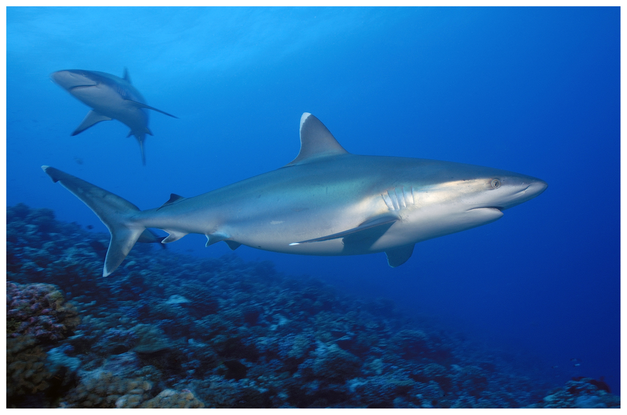

Figura 1. Tiburón silvertip (Carcharhinus albimarginatus)

Un estudio reciente utilizó por primera vez telemetría acústica para examinar los patrones de residencia y movimiento vertical de 23 *C. albimarginatus* durante un año ([Espinoza et al. 2015](https://www.researchgate.net/publication/277476736_Movement_patterns_of_silvertip_sharks_Carcharhinus_albimarginatus_on_coral_reefs)). Este set de datos es único y podría ayudar a determinar si esta especie es más activa durante durante horas de la noche, si existen diferencias entre sexos, y adem?s, si existen diferencias estacionales en la profundidad a la que nadan.

Cada estudiante deberá examinar la base de datos para determinar:

**(1)** ¿Cómo varia la profundidad de los tiburones (promedio +/- SD) de acuerdo al mes del año y según día/noche?.

**(2)** ¿Cómo varía la profundidad de los machos y hembras de acuerdo a la hora del día?

El objetivo de este ejercicio es generar dos gráficos en los que se demuestre el dominio de los los conceptos aprendidos en el curso.

Se espera que los estudiantes puedan generar gráficos similares a estos:

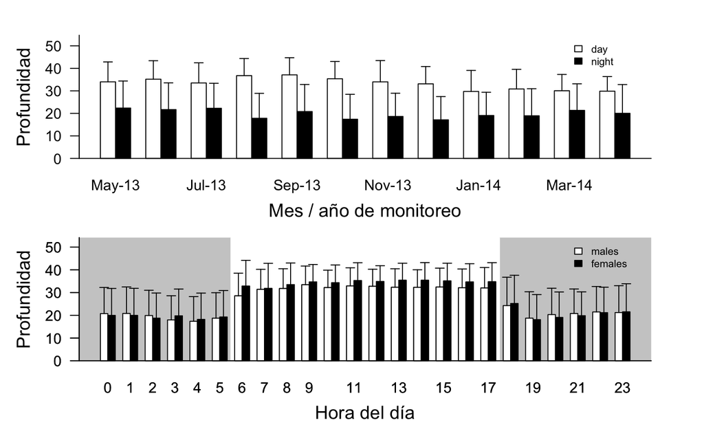

Otros gráficos que se podrían generar a partir de este set de datos son los siguientes:

[figure not shown]

Mario Espinoza, PhD